# Homework 9 solution

## Predicting life expectancy from GDP in the gapminder data

We will use data from the most recent year:

```r
gm2007 <- gapminder %>% filter(year == "2007")
```

In the rest of this homework, use `data = gm2007` the same way the lecture notes have used `data = candy_rankings`

### Show first few rows of data below

```r
head(gm2007)
```

```
## # A tibble: 6 x 6
##   country     continent  year lifeExp      pop gdpPercap
##   <fct>       <fct>     <int>   <dbl>    <int>     <dbl>
## 1 Afghanistan Asia       2007    43.8 31889923       975
## 2 Albania     Europe     2007    76.4  3600523      5937
## 3 Algeria     Africa     2007    72.3 33333216      6223
## 4 Angola      Africa     2007    42.7 12420476      4797
## 5 Argentina   Americas   2007    75.3 40301927     12779
## 6 Australia   Oceania    2007    81.2 20434176     34435
```

### Fit a linear model predicting life expectancy from GDP per capita

### Summary of the model

```r
gm_model <- lm(lifeExp ~ gdpPercap, data = gm2007)
summary(gm_model)
```

```
##
## Call:
## lm(formula = lifeExp ~ gdpPercap, data = gm2007)
##
## Residuals:
##    Min     1Q Median     3Q    Max
## -22.83  -6.32   1.92   6.90  13.13
##
## Coefficients:
##               Estimate Std. Error t value            Pr(>|t|)
## (Intercept) 59.5656501  1.0104086    59.0 <0.0000000000000002 ***
## gdpPercap    0.0006371  0.0000583    10.9 <0.0000000000000002 ***
## ---
## Signif. codes:  0 '***' 0.001 '**' 0.01 '*' 0.05 '.' 0.1 ' ' 1
##
## Residual standard error: 8.9 on 140 degrees of freedom
## Multiple R-squared:  0.461,  Adjusted R-squared:  0.457
## F-statistic:  120 on 1 and 140 DF,  p-value: <0.0000000000000002
```

### Confidence intervals for coefficients

```r
confint(gm_model)
```

```
##                  2.5 %     97.5 %
## (Intercept) 57.5680179 61.5632822
## gdpPercap    0.0005219  0.0007523
```

What is the lower limit of the 95% confidence interval for the GDP per capita coefficient?

The lower limit is 0.0005

### Diagnostic plots

Use the `autoplot()` function to show diagnostics below.

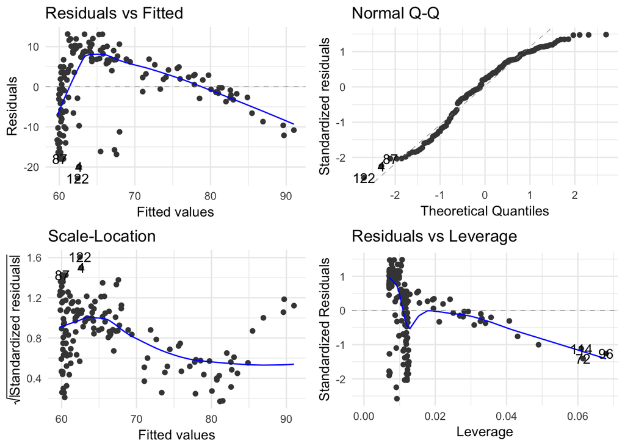

```r
autoplot(gm_model)
```

Is there a pattern in the residuals? Do the residuals seem approximately normally distributed?

There is a pattern in the residuals, first increasing and then decreasing as the fitted values increase (from left to right in the top left graph).

The Q-Q plot shows that some of the largest positive residuals are far from normally distributed (top right of the Q-Q plot).

### Transforming to log(GDP per capita)

```r
gm_log_model <- lm(lifeExp ~ log(gdpPercap), data = gm2007)
```

- Show diagnostic plots for this model. Do the residuals have any more or less of an obvious pattern in them? Do they seem any more or less normally distributed?

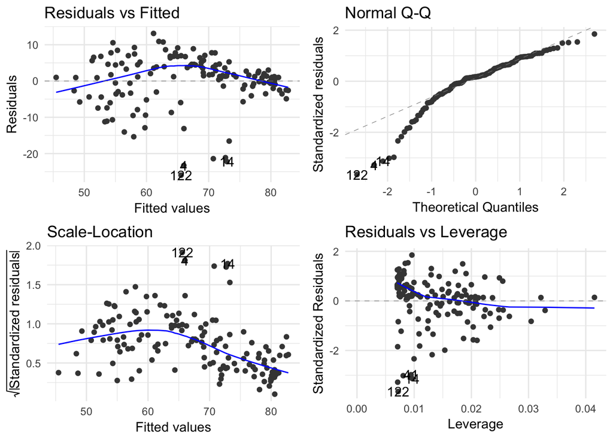

```r
autoplot(gm_log_model)
```

The residuals seem to have less of an obvious pattern than in the previous model.

In the Q-Q plot, the large negative residuals seem to be far from normally distributed.

### If you could add one more variable, what would it be?

Suppose we could add another variable to this dataset to include in the model. It could be anything related to a country’s economy, environment, consumption of specific goods, percent of population with access to high speed internet–anything like this that you can imagine. The goal is to better predict life expectancy and show that GDP and this other variable are important variables for predicting life expectancy. **(1)** Which variable would you pick, and why? **(2)** How would you interpret the fitted coefficient for this variable after it is added to the model?

Keep in mind that your ultimate goal is to tell an interesting story with the data.

**(1)** I would like to include a variable like “percent of population living in cities vs rural areas.” I expect that life expectancy is lower in rural areas, so this variable may be important for predicting the average life expectancy for a country.

**(2)** The coefficient for this variable would be the increase in predicted life expectancy for one percent increase in population living in cities, **holding gdp per capita constant**